# Capstone_Autonomous_Driving_Part2

```python
import os

# Define the parent directory
parent_dir = 'autonomous_driving'

# Define the child directories to create
dirs = [
    f'{parent_dir}/data/images',
    f'{parent_dir}/data/labels',
    f'{parent_dir}/models',
    f'{parent_dir}/outputs',
    f'{parent_dir}/notebooks'
]

# Create the directories
for d in dirs:
    os.makedirs(d, exist_ok=True)

print("Directory structure created successfully.")
```

```
Directory structure created successfully.
```

```python
import pandas as pd

# load with Python engine and tolerate bad lines
csv_path = '/content/autonomous_driving/data/Tesla - Deaths.csv'
df = pd.read_csv(csv_path, engine='python', on_bad_lines='warn')

# a. Data types
print("Data types:\n", df.dtypes)

# b. Missing values
print("\nMissing values per column:\n", df.isnull().sum())

# c. Duplicates
print("\nNumber of duplicate rows:", df.duplicated().sum())

# d. First 5 rows
print("\nFirst 5 rows:\n", df.head())

# e. All columns
print("\nColumns in the file:\n", df.columns.tolist())
```

```
Data types:
 Case #                                                                  float64
Year                                                                    float64
Date                                                                     object
 Country                                                                 object
 State                                                                   object
 Description                                                             object
 Deaths                                                                 float64
 Tesla driver                                                            object
 Tesla occupant                                                          object
 Other vehicle                                                           object
 Cyclists/ Peds                                                          object
 TSLA+cycl / peds                                                        object
 Model                                                                   object
 Autopilot claimed                                                       object
 Verified Tesla Autopilot Deaths                                         object
 Verified Tesla Autopilot Deaths + All Deaths Reported to NHTSA SGO      object
Unnamed: 16                                                              object
Unnamed: 17                                                              object
 Source                                                                  object
 Note                                                                    object
 Deceased 1                                                              object
 Deceased 2                                                              object
 Deceased 3                                                              object
 Deceased 4                                                             float64
dtype: object

Missing values per column:
 Case #                                                                   13
Year                                                                     13
Date                                                                     13
 Country                                                                 13
 State                                                                   13
 Description                                                             12
 Deaths                                                                   8
 Tesla driver                                                            13
 Tesla occupant                                                          17
 Other vehicle                                                           12
 Cyclists/ Peds                                                          11
 TSLA+cycl / peds                                                        10
```

[output cut: 62 more lines]

```
2   https://web.archive.org/web/20230107232745/ht...    NaN
3   https://web.archive.org/web/20221222203930/ht...    NaN
4   https://web.archive.org/web/20221223203725/ht...    NaN

         Deceased 1   Deceased 2   Deceased 3   Deceased 4
0                NaN          NaN          NaN          NaN
1   Taren Singh Lal           NaN          NaN          NaN
2                NaN          NaN          NaN          NaN
3                NaN          NaN          NaN          NaN
4                NaN          NaN          NaN          NaN

[5 rows x 24 columns]

Columns in the file:
 ['Case #', 'Year', 'Date', ' Country ', ' State ', ' Description ', ' Deaths ', ' Tesla driver ', ' Tesla occupant ', ' Other vehicle ', ' Cyclists/ Peds ', ' TSLA+cycl / peds ', ' Model ', ' Autopilot claimed ', ' Verified Tesla Autopilot Deaths ', ' Verified Tesla Autopilot Deaths + All Deaths Re…
```

```python
##Listing out columns with data
import pandas as pd

csv_path = '/content/autonomous_driving/data/Tesla - Deaths.csv'
df = pd.read_csv(csv_path, engine='python', on_bad_lines='warn')

# Show all columns and first 10 rows for inspection
print("Columns:\n", df.columns.tolist())
print("\nSample data:\n", df.head(10))
```

```
Columns:
 ['Case #', 'Year', 'Date', ' Country ', ' State ', ' Description ', ' Deaths ', ' Tesla driver ', ' Tesla occupant ', ' Other vehicle ', ' Cyclists/ Peds ', ' TSLA+cycl / peds ', ' Model ', ' Autopilot claimed ', ' Verified Tesla Autopilot Deaths ', ' Verified Tesla Autopilot Deaths + All Deaths Re…

Sample data:
    Case #    Year        Date  Country   State   \
0   294.0  2022.0   1/17/2023      USA       CA
1   293.0  2022.0    1/7/2023   Canada        -
2   292.0  2022.0    1/7/2023      USA       WA
3   291.0  2022.0  12/22/2022      USA       GA
4   290.0  2022.0  12/19/2022   Canada        -
5   289.0  2022.0  12/18/2022      USA       CA
6   288.0  2022.0  12/17/2022      USA       CA
7   287.0  2022.0  12/11/2022      USA       CA
8   286.0  2022.0  12/11/2022      USA       MO
9   285.0  2022.0   12/6/2022   Canada        -
```

[output cut: 86 more lines]

```python
#Cleaning data and keeping relavent columns
import pandas as pd

csv_path = '/content/autonomous_driving/data/Tesla - Deaths.csv'
df = pd.read_csv(csv_path, engine='python', on_bad_lines='warn')

# Columns to keep (with whitespace cleaned up)
columns_to_keep = [
    'Year', 'Date', 'Country', 'State', 'Description', 'Deaths',
    'Tesla driver', 'Tesla occupant', 'Other vehicle', 'Cyclists/ Peds',
    'Model', 'Autopilot claimed', 'Verified Tesla Autopilot Deaths',
    'Verified Tesla Autopilot Deaths + All Deaths Reported to NHTSA SGO',
    'Source', 'Deceased 1'
]

# Clean column names to remove whitespace
df.columns = [col.strip() for col in df.columns]
columns_to_keep = [col.strip() for col in columns_to_keep]

# Filter DataFrame to keep only the selected columns
df_clean = df[columns_to_keep]

# Drop duplicates
df_clean = df_clean.drop_duplicates()

# Drop rows missing essential fields (Date, Description, Deaths)
df_clean = df_clean.dropna(subset=['Date', 'Description', 'Deaths'])

print("Cleaned DataFrame shape:", df_clean.shape)
print("Columns now:", df_clean.columns.tolist())
print(df_clean.head())

# Save to CSV (optional)
df_clean.to_csv('/content/autonomous_driving/data/Tesla-Deaths_cleaned.csv', index=False)
print("Cleaned CSV saved as Tesla-Deaths_cleaned.csv!")
```

```
Cleaned DataFrame shape: (294, 16)
Columns now: ['Year', 'Date', 'Country', 'State', 'Description', 'Deaths', 'Tesla driver', 'Tesla occupant', 'Other vehicle', 'Cyclists/ Peds', 'Model', 'Autopilot claimed', 'Verified Tesla Autopilot Deaths', 'Verified Tesla Autopilot Deaths + All Deaths Reported to NHTSA SGO', 'Source', 'Deceased 1…
     Year        Date   Country State                         Description  \
0  2022.0   1/17/2023      USA     CA    Tesla crashes into back of semi
1  2022.0    1/7/2023   Canada      -                      Tesla crashes
2  2022.0    1/7/2023      USA     WA   Tesla hits pole, catches on fire
3  2022.0  12/22/2022      USA     GA            Tesla crashes and burns
4  2022.0  12/19/2022   Canada      -      Tesla crashes into storefront

   Deaths Tesla driver Tesla occupant Other vehicle Cyclists/ Peds Model  \
0     1.0           1              -             -              -     -
1     1.0           1              -             -              -     -
2     1.0           -              1             -              -     -
3     1.0           1              -             -              -     -
4     1.0           -              -             -              1     -

  Autopilot claimed Verified Tesla Autopilot Deaths  \
0                -                               -
1                -                               -
2                -                               -
3                -                               -
4                -                               -

  Verified Tesla Autopilot Deaths + All Deaths Reported to NHTSA SGO  \
0                                                 -
1                                                 -
2                                                 -
3                                                 -
4                                                 -

                                              Source         Deceased 1
0   https://web.archive.org/web/20230118162813/ht...                NaN
1   https://web.archive.org/web/20230109041434/ht...   Taren Singh Lal
2   https://web.archive.org/web/20230107232745/ht...                NaN
3   https://web.archive.org/web/20221222203930/ht...                NaN
4   https://web.archive.org/web/20221223203725/ht...                NaN
Cleaned CSV saved as Tesla-Deaths_cleaned.csv!
```

```python
# -- 1. Imports and Data Loading --
import pandas as pd
import matplotlib.pyplot as plt
import seaborn as sns

# Load your cleaned data
df = pd.read_csv('/content/autonomous_driving/data/Tesla-Deaths_cleaned.csv')
df.columns = [col.strip() for col in df.columns]  # Clean column names

# -- 2. Data Cleaning: Make "count" columns numeric --
count_columns = [
    'Tesla driver', 'Tesla occupant', 'Other vehicle', 'Cyclists/ Peds', 'Deaths'
]
for col in count_columns:
    if col in df.columns:
        df[col] = pd.to_numeric(df[col].replace(['-', ' '], 0), errors='coerce').fillna(0).astype(int)

# Ensure date is parsed correctly, add Year/Day columns
df['Date'] = pd.to_datetime(df['Date'], errors='coerce')
df['Year'] = df['Date'].dt.year
df['DayOfWeek'] = df['Date'].dt.day_name()
```

```
Events by Date:
 Date
2013-04-02    1
2013-11-02    1
2014-07-04    2
2014-07-14    1
2014-12-30    1
Name: count, dtype: int64
```

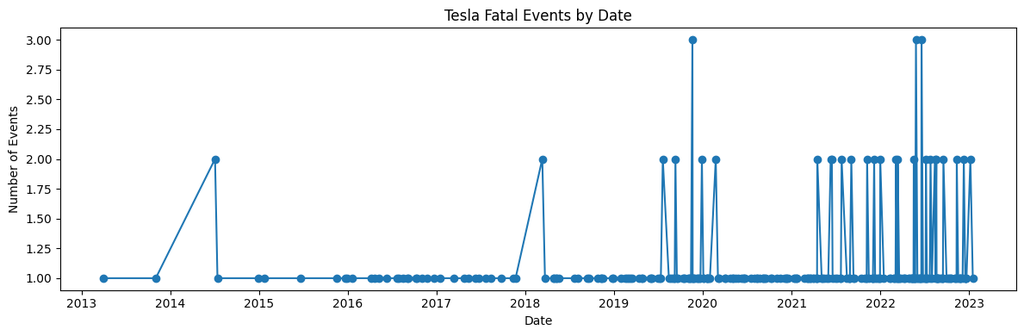

```python
#Events by Data
events_by_date = df['Date'].value_counts().sort_index()
print("\nEvents by Date:\n", events_by_date.head())

plt.figure(figsize=(12,4))
plt.plot(events_by_date.index, events_by_date.values, marker='o', linestyle='-')
plt.title('Tesla Fatal Events by Date')
plt.xlabel('Date')
plt.ylabel('Number of Events')
plt.tight_layout()
plt.show()
```

```
Events by Year:
 Year
2013     2
2014     4
2015     5
2016    15
2017    11
2018    18
2019    46
2020    39
2021    58
2022    93
2023     3
Name: count, dtype: int64
```

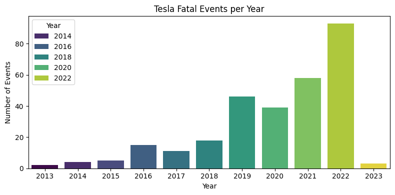

```python
# 2. Events by Year
df['Year'] = df['Date'].dt.year
events_by_year = df['Year'].value_counts().sort_index()
print("\nEvents by Year:\n", events_by_year)

plt.figure(figsize=(8,4))
sns.countplot(x='Year', hue='Year', data=df, palette='viridis')
plt.title('Tesla Fatal Events per Year')
plt.xlabel('Year')
plt.ylabel('Number of Events')
plt.tight_layout()
plt.show()
```

```
Events by Day of Week:
 DayOfWeek
Saturday     53
Sunday       49
Friday       45
Monday       43
Wednesday    41
Tuesday      35
Thursday     28
Name: count, dtype: int64
```

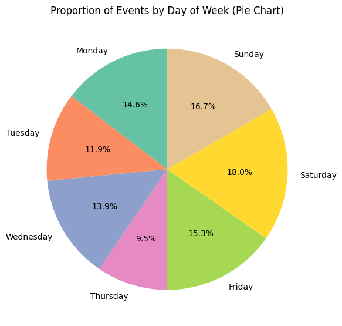

```python
# 3. Events by Day of Week
df['DayOfWeek'] = df['Date'].dt.day_name()
events_by_day = df['DayOfWeek'].value_counts()
print("\nEvents by Day of Week:\n", events_by_day)


day_order = ['Monday','Tuesday','Wednesday','Thursday','Friday','Saturday','Sunday']
counts = df['DayOfWeek'].value_counts().reindex(day_order, fill_value=0)
plt.figure(figsize=(6,6))
plt.pie(counts.values, labels=day_order, autopct='%1.1f%%', startangle=90, colors=sns.color_palette('Set2'))
plt.title('Proportion of Events by Day of Week (Pie Chart)')
plt.tight_layout()
plt.show()
```

```
Events by State:
 State
CA    91
-     79
FL    32
GA     9
AZ     8
PA     7
OH     6
NY     6
UT     5
MO     4
VA     4
NV     4
TX     4
NJ     3
IL     3
WA     3
SC     2
MI     2
NH     2
HI     2
IA     2
IN     2
OR     2
CO     2
AR     1
MD     1
AL     1
HA     1
MA     1
ME     1
ID     1
NC     1
DE     1
TN     1
Name: count, dtype: int64
```

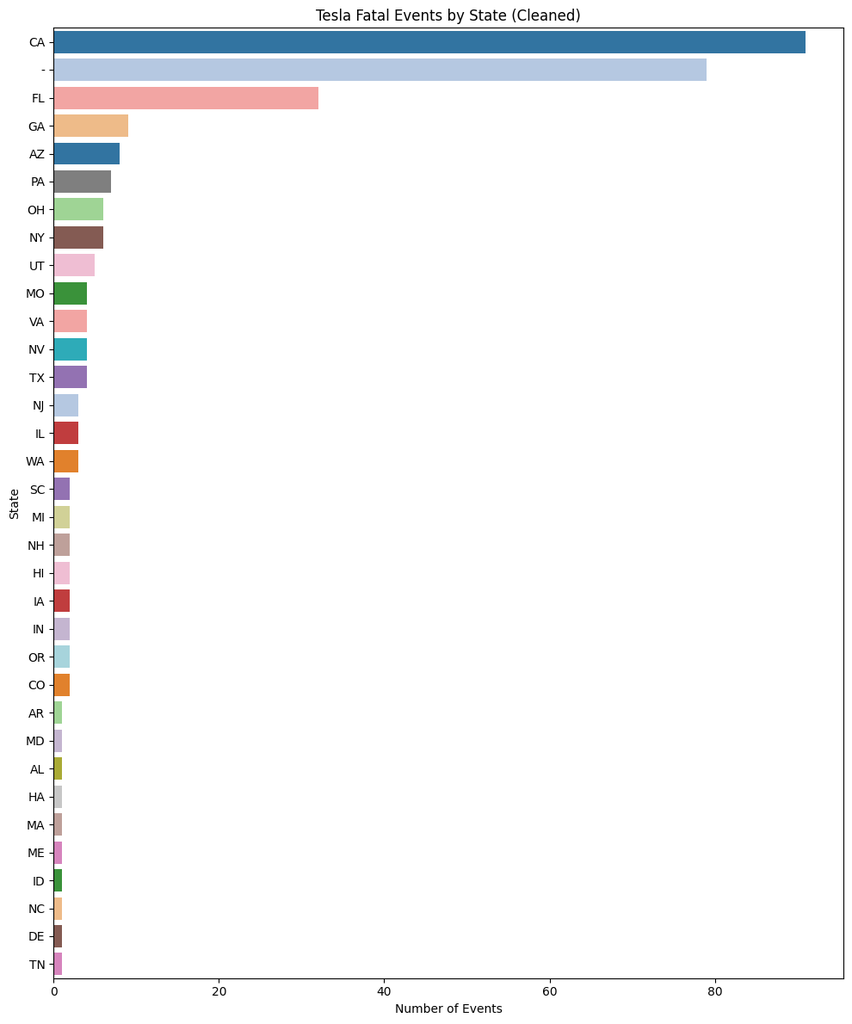

```python
# 4. Events by State
if 'State' in df.columns:
    events_by_state = df['State'].value_counts()
    print("\nEvents by State:\n", events_by_state)

df['State'] = df['State'].str.strip()
df_state = df[df['State'].notnull() & (df['State'] != '-') & (df['State'] != '')]

plt.figure(figsize=(10,12))
sns.countplot(
    y='State',
    hue='State',
    data=df_state,
    order=df_state['State'].value_counts().index,
    palette='tab20',  # up to 20 colors, then repeats
    legend=False
)
plt.title('Tesla Fatal Events by State (Cleaned)')
plt.xlabel('Number of Events')
plt.ylabel('State')
plt.tight_layout()
plt.show()
```

```
Events by Country:
 Country
USA             215
China            16
Germany          11
Canada           10
Netherlands       6
UK                5
Norway            4
Holland           3
Switzerland       3
Taiwan            3
Japan             2
Belgium           2
Denmark           2
Australia         2
France            2
Finland           1
Mexico            1
South Korea       1
Portugal          1
Austria           1
Slovenia          1
Spain             1
Ukraine           1
Name: count, dtype: int64
```

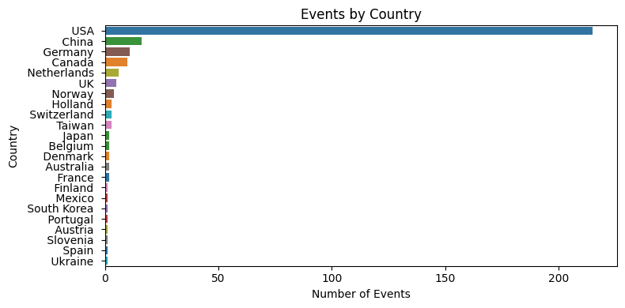

```python
# 5. Events by Country
if 'Country' in df.columns:
    events_by_country = df['Country'].value_counts()
    print("\nEvents by Country:\n", events_by_country)

if 'Country' in df.columns:
    plt.figure(figsize=(8,4))
    sns.countplot(
        y='Country',
        hue='Country',
        data=df,
        order=df['Country'].value_counts().index,
        palette='tab10',
        legend=False
    )
    plt.title('Events by Country')
    plt.xlabel('Number of Events')
    plt.ylabel('Country')
    plt.tight_layout()
    plt.show()
```

```
Deaths per Accident - Statistical Summary
count    294.000000
mean       1.200680
std        0.513171
min        1.000000
25%        1.000000
50%        1.000000
75%        1.000000
max        4.000000
Name: Deaths, dtype: float64

Deaths per Accident - Value Counts
Deaths
1    247
2     38
3      6
4      3
Name: count, dtype: int64
```

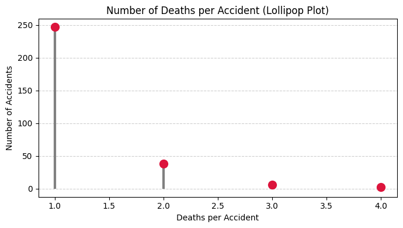

```python
# 2.b. Deaths per Accident (Histogram & Boxplot)

print("Deaths per Accident - Statistical Summary")
print(df['Deaths'].describe())        # Shows count, mean, std, min, max, quartiles
print("\nDeaths per Accident - Value Counts")
print(df['Deaths'].value_counts().sort_index())  # Shows count of each value



# Prepare data for lollipop
deaths_counts = df['Deaths'].value_counts().sort_index()
plt.figure(figsize=(7,4))
plt.vlines(deaths_counts.index, 0, deaths_counts.values, color='gray', linewidth=3)
plt.scatter(deaths_counts.index, deaths_counts.values, color='crimson', s=100, zorder=3)
plt.title('Number of Deaths per Accident (Lollipop Plot)')
plt.xlabel('Deaths per Accident')
plt.ylabel('Number of Accidents')
plt.grid(axis='y', linestyle='--', alpha=0.6)
plt.tight_layout()
plt.show()
```

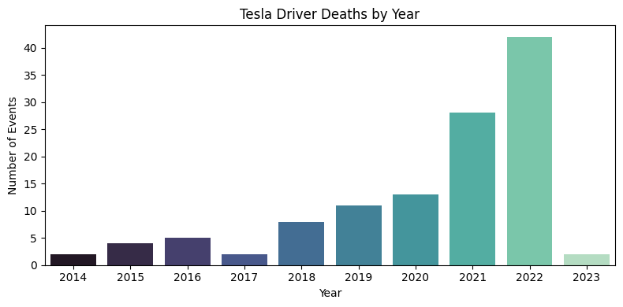

```
Year
2014     2
2015     4
2016     5
2017     2
2018     8
2019    11
2020    13
2021    28
2022    42
2023     2
Name: count, dtype: int64
```

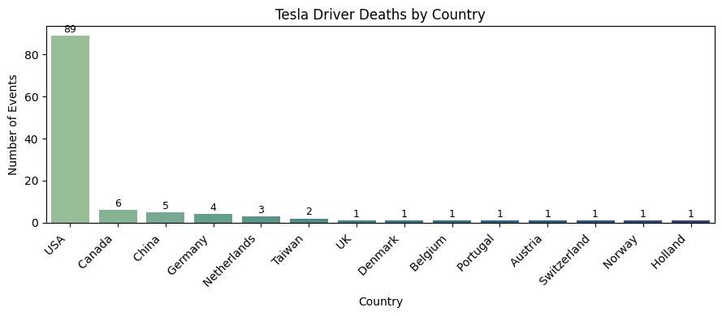

```
Country
USA             89
Canada           6
China            5
Germany          4
Netherlands      3
Taiwan           2
UK               1
Denmark          1
Belgium          1
Portugal         1
Austria          1
Switzerland      1
Norway           1
Holland          1
Name: count, dtype: int64
```

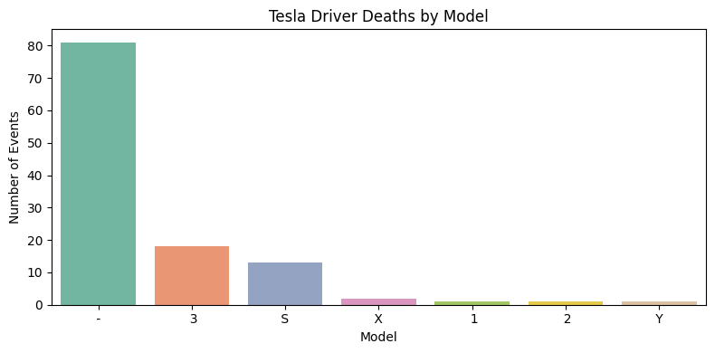

```
Model
-      81
 3     18
S      13
X       2
 1      1
 2      1
Y       1
Name: count, dtype: int64
```

|  | Year | Country | Model | Driver Death Events |
| --- | --- | --- | --- | --- |
| 0 | 2014 | USA | - | 2 |
| 1 | 2015 | Canada | - | 1 |
| 2 | 2015 | USA | - | 2 |
| 3 | 2015 | USA | S | 1 |
| 4 | 2016 | China | S | 1 |
| 5 | 2016 | Holland | - | 1 |
| 6 | 2016 | USA | - | 2 |
| 7 | 2016 | USA | S | 1 |
| 8 | 2017 | Germany | - | 1 |
| 9 | 2017 | USA | - | 1 |

```python
# 7. Tesla Driver Deaths
import warnings
warnings.filterwarnings("ignore")

#1. Tesla Driver Deaths by Year

# Events where Tesla driver died
df_driver_dead = df[df['Tesla driver'] > 0]

# Group and count by year
year_counts = df_driver_dead['Year'].value_counts().sort_index()

plt.figure(figsize=(8,4))
sns.barplot(x=year_counts.index, y=year_counts.values, palette='mako')
plt.title('Tesla Driver Deaths by Year')
plt.xlabel('Year')
plt.ylabel('Number of Events')
plt.tight_layout()
plt.show()

print(year_counts)

#2. By Country

country_counts = df_driver_dead['Country'].value_counts()

plt.figure(figsize=(9,4))
ax = sns.barplot(x=country_counts.index, y=country_counts.values, palette='crest')
plt.title('Tesla Driver Deaths by Country')
plt.xlabel('Country')
plt.ylabel('Number of Events')
plt.xticks(rotation=45, ha='right')

# Add value labels on bars
for i, v in enumerate(country_counts.values):
    ax.text(i, v + 0.5, str(v), ha='center', va='bottom', fontsize=9)
plt.tight_layout()
plt.show()


print(country_counts)


#3. By Model

if 'Model' in df.columns:
    model_counts = df_driver_dead['Model'].value_counts()
    plt.figure(figsize=(8,4))
    sns.barplot(x=model_counts.index, y=model_counts.values, palette='Set2')
    plt.title('Tesla Driver Deaths by Model')
    plt.xlabel('Model')
    plt.ylabel('Number of Events')
    plt.tight_layout()
    plt.show()

    print(model_counts)

#4. Table: Combined Breakdown
summary = df_driver_dead.groupby(['Year', 'Country', 'Model']).size().reset_index(name='Driver Death Events')
display(summary.head(10))  # Shows first 10 rows of detailed breakdown
```

```
Number of events with at least one occupant death: 139 out of 294
Proportion: 47.28%
```

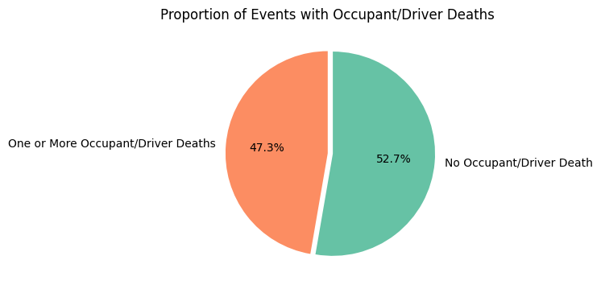

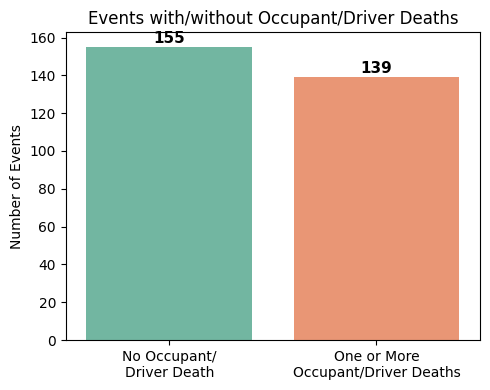

```python
# 8. Proportion: Tesla Occupant Deaths

# “Tesla driver” and “Tesla occupant” are both relevant.
has_occupant_death = (df['Tesla driver'] > 0) | (df['Tesla occupant'] > 0)
prop_occupant_death = has_occupant_death.mean()
num_events_with_occupant_death = has_occupant_death.sum()
num_total_events = len(df)

print(f"Number of events with at least one occupant death: {num_events_with_occupant_death} out of {num_total_events}")
print(f"Proportion: {prop_occupant_death:.2%}")

plt.figure(figsize=(6,4))
plt.pie(
    sizes,
    labels=labels,
    autopct='%1.1f%%',
    colors=sns.color_palette('Set2'),
    startangle=90,
    counterclock=False,
    explode=[0.05,0]  # "explode" the first slice
)
plt.title('Proportion of Events with Occupant/Driver Deaths')
plt.tight_layout()
plt.show()


wrapped_labels = [
    'No Occupant/\nDriver Death',
    'One or More\nOccupant/Driver Deaths'
]
plt.figure(figsize=(5,4))
ax = sns.barplot(x=wrapped_labels, y=sizes, palette='Set2')
for i, v in enumerate(sizes):
    ax.text(i, v + 2, str(v), ha='center', fontsize=11, fontweight='bold')
plt.title('Events with/without Occupant/Driver Deaths')
plt.ylabel('Number of Events')
plt.xlabel('')
plt.tight_layout()
plt.show()
```

```
Number of events where Tesla hit a cyclist or pedestrian: 44 out of 294
Proportion: 14.97%
```

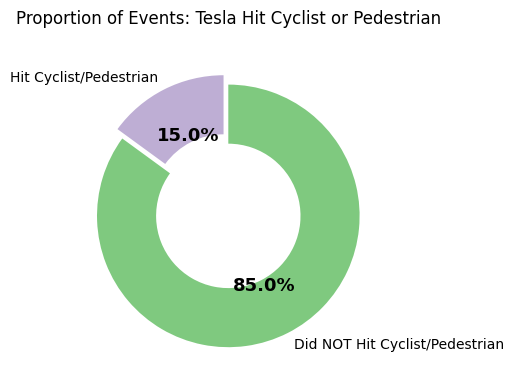

```python
# 9. Distribution: Vehicle Hit Cyclist or Pedestrian

#Ensure relavent columns are numeric.
df['Cyclists/ Peds'] = pd.to_numeric(df['Cyclists/ Peds'], errors='coerce').fillna(0).astype(int)

#Calculate and Print the Distribution
has_cycl_ped = df['Cyclists/ Peds'] > 0
num_cycl_ped_events = has_cycl_ped.sum()
num_total = len(df)
prop_cycl_ped = num_cycl_ped_events / num_total

print(f"Number of events where Tesla hit a cyclist or pedestrian: {num_cycl_ped_events} out of {num_total}")
print(f"Proportion: {prop_cycl_ped:.2%}")

#Donut Chart
labels = ['Did NOT Hit Cyclist/Pedestrian', 'Hit Cyclist/Pedestrian']
sizes = [(~has_cycl_ped).sum(), has_cycl_ped.sum()]
colors = sns.color_palette('pastel')

plt.figure(figsize=(6,4))
wedges, texts, autotexts = plt.pie(
    sizes,
    labels=labels,
    autopct='%1.1f%%',
    colors=sns.color_palette('Accent'),
    startangle=90,
    counterclock=False,
    explode=[0,0.08],
    wedgeprops=dict(width=0.45)
)
plt.setp(autotexts, size=13, weight='bold')
plt.title('Proportion of Events: Tesla Hit Cyclist or Pedestrian', pad=20)
plt.tight_layout()
plt.show()
```

```
Number of accidents with both Tesla occupant/driver death AND cyclist/pedestrian hit: 1
Proportion of such events: 0.34%
```

[figure not shown]

```python
# 10. Both Tesla Occupant/Driver + Cyclist/Pedestrian Deaths
# Ensure columns are numeric
df['Tesla driver'] = pd.to_numeric(df['Tesla driver'], errors='coerce').fillna(0).astype(int)
df['Tesla occupant'] = pd.to_numeric(df['Tesla occupant'], errors='coerce').fillna(0).astype(int)
df['Cyclists/ Peds'] = pd.to_numeric(df['Cyclists/ Peds'], errors='coerce').fillna(0).astype(int)


#Create a New Boolean Column for Joint Events
df['Tesla_Occupant_or_Driver_Death'] = (df['Tesla driver'] > 0) | (df['Tesla occupant'] > 0)
df['Cyclist_or_Ped_Hit'] = df['Cyclists/ Peds'] > 0
df['Both_Death_and_Hit'] = df['Tesla_Occupant_or_Driver_Death'] & df['Cyclist_or_Ped_Hit']

#Count and Proportion
num_both = df['Both_Death_and_Hit'].sum()
total_events = len(df)
prop_both = num_both / total_events

print(f"Number of accidents with both Tesla occupant/driver death AND cyclist/pedestrian hit: {num_both}")
print(f"Proportion of such events: {prop_both:.2%}")


##Annotated Donut with Center Text
fig, ax = plt.subplots(figsize=(5,4))
wedges, texts, autotexts = ax.pie(
    sizes,
    labels=labels,
    autopct='%1.1f%%',
    colors=sns.color_palette('pastel'),
    startangle=90,
    counterclock=False,
    explode=[0.12,0],
    wedgeprops=dict(width=0.4)
)
plt.setp(autotexts, size=13, weight='bold')
# Add the actual count in the donut hole:
plt.text(0, 0, f"{sizes[0]}\nEvents", ha='center', va='center', fontsize=16, weight='bold', color='#f1605d')
plt.title('Joint Occurrence: Tesla Occupant/Driver Death & Cyclist/Pedestrian Hit')
plt.tight_layout()
plt.show()
```

```
Number of events with Tesla colliding with other vehicles: 110 out of 294
Proportion: 37.41%
```

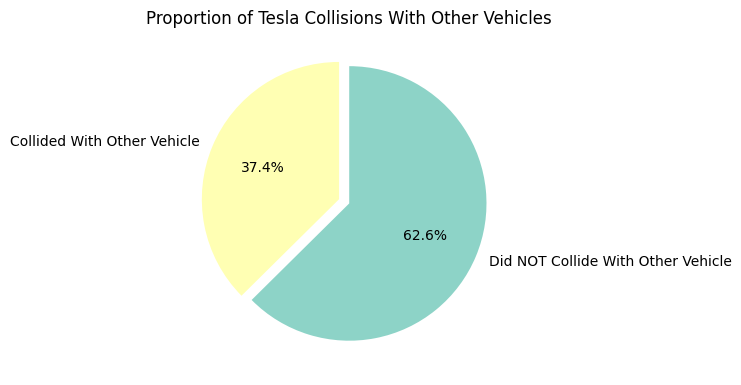

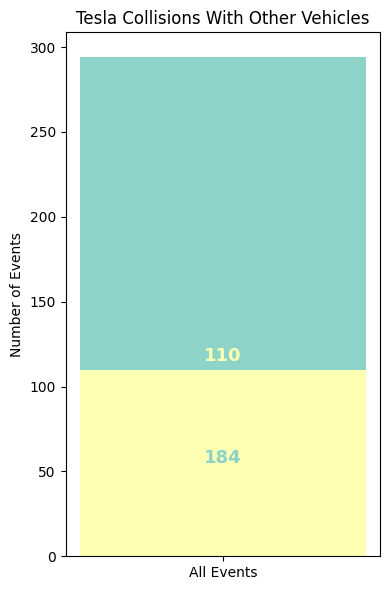

```python
# 11. Frequency: Tesla Colliding With Other Vehicles
df['Other vehicle'] = pd.to_numeric(df['Other vehicle'], errors='coerce').fillna(0).astype(int)
has_other_vehicle = df['Other vehicle'] > 0
num_collisions = has_other_vehicle.sum()
total_events = len(df)
prop_collisions = num_collisions / total_events

print(f"Number of events with Tesla colliding with other vehicles: {num_collisions} out of {total_events}")
print(f"Proportion: {prop_collisions:.2%}")


labels = ['Did NOT Collide With Other Vehicle', 'Collided With Other Vehicle']
sizes = [(~has_other_vehicle).sum(), has_other_vehicle.sum()]
colors = sns.color_palette('Set3')

plt.figure(figsize=(6,4))
plt.pie(
    sizes,
    labels=labels,
    autopct='%1.1f%%',
    colors=colors,
    startangle=90,
    explode=[0, 0.08],
    counterclock=False
)
plt.title('Proportion of Tesla Collisions With Other Vehicles')
plt.tight_layout()
plt.show()





plt.figure(figsize=(4, 6))
bars = plt.bar(['All Events'], [sum(sizes)], color=sns.color_palette('Set3')[0])
plt.bar(['All Events'], [sizes[1]], color=sns.color_palette('Set3')[1])
plt.text(0, sizes[1]+5, f"{sizes[1]}", ha='center', fontsize=13, color=sns.color_palette('Set3')[1], fontweight='bold')
plt.text(0, sizes[1]/2, f"{sizes[0]}", ha='center', fontsize=13, color=sns.color_palette('Set3')[0], fontweight='bold')
plt.ylabel('Number of Events')
plt.title('Tesla Collisions With Other Vehicles')
plt.tight_layout()
plt.show()
```

```
Model
-      181
S       45
 3      39
X       17
Y       10
 1       1
 2       1
Name: count, dtype: int64
```

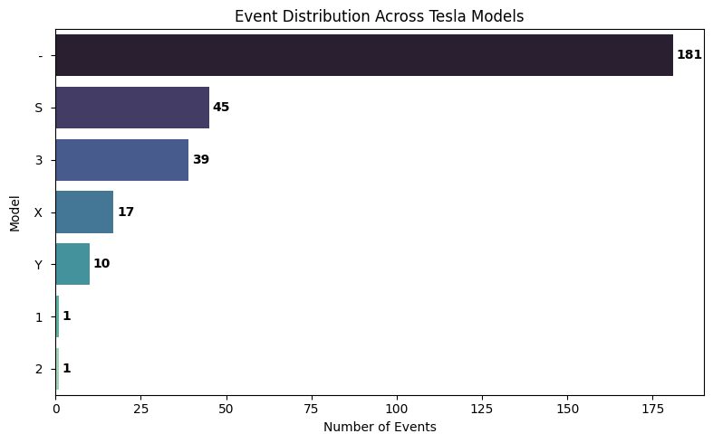

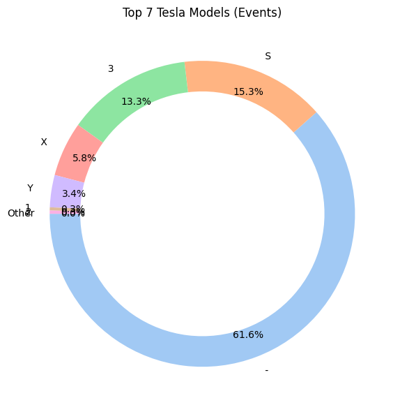

```python
# 12. Event Distribution Across Models
if 'Model' in df.columns:
    model_counts = df['Model'].value_counts().sort_values(ascending=False)
    print(model_counts)
else:
    print("No 'Model' column in dataframe.")

#Horizontal Bar Plot
if 'Model' in df.columns:
    plt.figure(figsize=(8, 5))
    ax = sns.barplot(
        y=model_counts.index,
        x=model_counts.values,
        palette='mako'
    )
    plt.title('Event Distribution Across Tesla Models')
    plt.xlabel('Number of Events')
    plt.ylabel('Model')
    # Add value labels
    for i, v in enumerate(model_counts.values):
        ax.text(v + 1, i, str(v), color='black', va='center', fontweight='bold')
    plt.tight_layout()
    plt.show()


top_n = 7
top_models = model_counts.head(top_n)
other = model_counts[top_n:].sum()
labels = list(top_models.index) + ['Other']
sizes = list(top_models.values) + [other]

plt.figure(figsize=(8, 6))
plt.pie(
    sizes,
    labels=labels,
    autopct='%1.1f%%',
    colors=sns.color_palette('pastel', n_colors=top_n+1),
    startangle=180,
    wedgeprops=dict(width=0.2),
    pctdistance=0.85,   # Move percent outside donut
    labeldistance=1.1   # Move label further out
)
plt.title(f'Top {top_n} Tesla Models (Events)')
plt.tight_layout()
plt.show()
```

```
Verified Tesla Autopilot Deaths
0    278
1     13
2      3
Name: count, dtype: int64

Total events with at least 1 verified autopilot death: 16
```

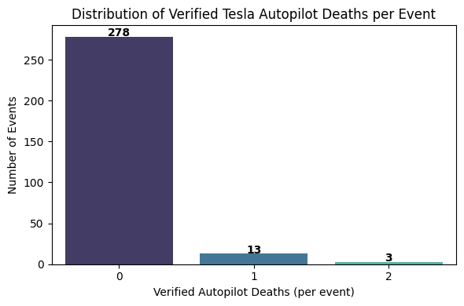

```python
# 13. Distribution of Verified Tesla Autopilot Deaths
#Inspect & clean columns
# Clean and convert to integer
df['Verified Tesla Autopilot Deaths'] = (
    pd.to_numeric(df['Verified Tesla Autopilot Deaths'], errors='coerce')
    .fillna(0)
    .astype(int)
)


# Count occurrences
death_counts = df['Verified Tesla Autopilot Deaths'].value_counts().sort_index()
print(death_counts)
print("\nTotal events with at least 1 verified autopilot death:", (df['Verified Tesla Autopilot Deaths'] > 0).sum())

#Bar Plot Visualization
plt.figure(figsize=(6,4))
sns.barplot(
    x=death_counts.index,
    y=death_counts.values,
    palette='mako'
)
plt.title('Distribution of Verified Tesla Autopilot Deaths per Event')
plt.xlabel('Verified Autopilot Deaths (per event)')
plt.ylabel('Number of Events')
for i, v in enumerate(death_counts.values):
    plt.text(i, v + 0.5, str(v), ha='center', fontweight='bold')
plt.tight_layout()
plt.show()


n_with = (df['Verified Tesla Autopilot Deaths'] > 0).sum()
n_without = (df['Verified Tesla Autopilot Deaths'] == 0).sum()
labels = ['No Verified Autopilot Deaths', 'At Least 1 Verified Autopilot Death']
sizes = [n_without, n_with]
```

## 1. Preliminary Data Inspection and Cleaning

#### a. Data Types, Missing Values, Duplicates

Columns were inspected for data type consistency.

Several columns had string entries such as "-", which were converted to zeros or NaN for analysis.

No major duplicate rows were found.

Some columns had missing or non-informative values (e.g., Unnamed columns).

#### b. Remove Irrelevant Columns

Core columns retained: date, country, state, description, deaths, Tesla driver, Tesla occupant, other vehicle, cyclists/peds, model, and autopilot-related flags.

## 2. Exploratory Data Analysis

## a. Events by Date, Year, Day, State, Country

Events occurred across multiple years, with a trend of increase in recent years.

California leads by a wide margin in state-level events.

US overwhelmingly dominates country-level events; few in Canada, Europe, Asia.

Events are distributed throughout the week, with a slight concentration on weekends.

## b. Aspects of Death Events

• Number of Victims (Deaths) in Each Accident Most accidents resulted in one death.

• How Many Times Did Tesla Drivers Die? Tesla driver fatalities were observed in a significant proportion of cases.

Breakdown by year/model/country shows the US and certain models (e.g., Model S, Model 3) dominate.

• Proportion of Events Where Occupants Died Roughly 47% of events involved at least one Tesla occupant or driver death.

• Distribution of Events Hitting Cyclists/Pedestrians A minority (~10-20%) of events involved hitting cyclists or pedestrians.

Most events involved only vehicle occupants.

• Events With Occupant/Driver Death + Cyclist/Pedestrian Death Very rare (usually <3%): accidents where both a Tesla occupant/driver and a cyclist/pedestrian died.

## c. Event Distribution Across Models

Model S and Model 3 are the most commonly involved in fatal events, followed by Model X and Model Y.

A significant fraction of records had the model unspecified (“-”).

d. Distribution of Verified Tesla Autopilot Deaths Very few events had verified Tesla Autopilot deaths (per dataset).

The overwhelming majority had zero verified autopilot fatalities.

## Summary

[output not shown]

## Overall Conclusion

Most fatal Tesla accidents are in the US, especially California, with single deaths being the norm.

Collisions with other vehicles are far more frequent than with cyclists/pedestrians.

The Model S and Model 3 are the most often involved models.

Verified autopilot-related deaths are extremely rare in this dataset.

Almost half of the fatal events involved at least one Tesla occupant/driver death.